# homework3solutions

Noah Moyer

2023-02-12

```r
#read in the required packages
library(tidyverse)
library(tidymodels)
```

```r
library(ggplot2)
library(kableExtra)
library(here)
library(kknn)
library(naniar)
library(corrplot)
library(corrr)
library(discrim)
tidymodels_prefer()
```

```r
#read in the dataset
titanic <- read.csv(here("Homework", "Homework3", "data", "titanic.csv"))

#investigate the data
head(titanic)
```

```
##   passenger_id survived pclass
## 1            1       No      3
## 2            2      Yes      1
## 3            3      Yes      3
## 4            4      Yes      1
## 5            5       No      3
## 6            6       No      3
##                                                  name    sex age sib_sp parch
## 1                             Braund, Mr. Owen Harris   male  22      1     0
## 2 Cumings, Mrs. John Bradley (Florence Briggs Thayer) female  38      1     0
## 3                              Heikkinen, Miss. Laina female  26      0     0
## 4        Futrelle, Mrs. Jacques Heath (Lily May Peel) female  35      1     0
## 5                            Allen, Mr. William Henry   male  35      0     0
## 6                                    Moran, Mr. James   male  NA      0     0
##             ticket    fare cabin embarked
## 1        A/5 21171  7.2500  <NA>        S
## 2         PC 17599 71.2833   C85        C
## 3 STON/O2. 3101282  7.9250  <NA>        S
## 4           113803 53.1000  C123        S
## 5           373450  8.0500  <NA>        S
## 6           330877  8.4583  <NA>        Q
```

```r
dim(titanic)
```

```
## [1] 891  12
```

```r
#change variables survived and pclass to factors
titanic$survived <- factor(titanic$survived, levels=c("Yes", "No")) #levels is used to order yes before no
titanic$pclass <- factor(titanic$pclass)
```

### Question 1

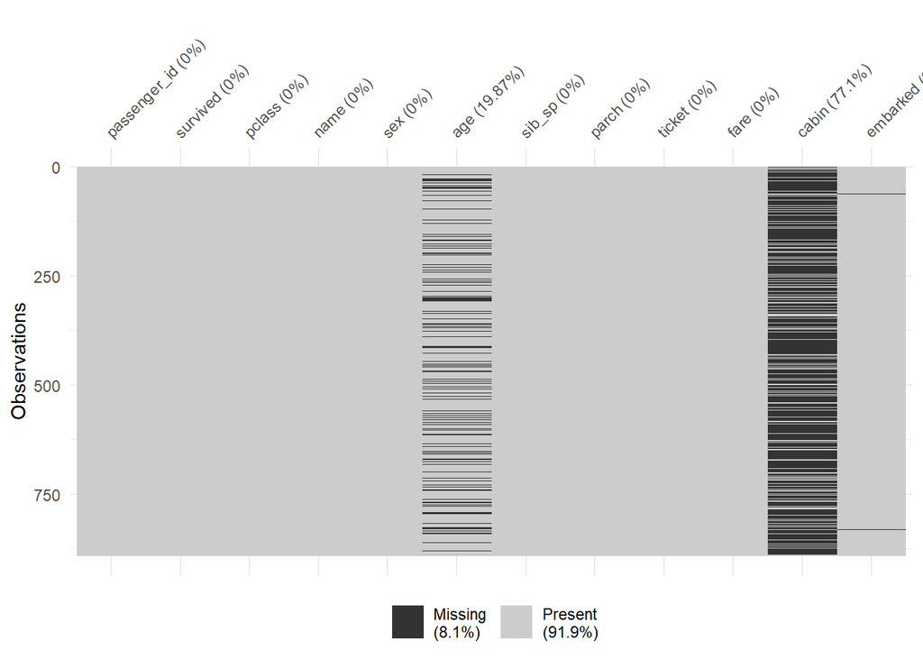

```r
#dealing with missingness, first lets look at how much data is missing
vis_miss(titanic)
```

I am not worried about cabin number missing, this will not be important in our predicts, I will remove that variable. Age I am concerned about because age should be a very important predictor of who lived and who died. Since I don’t want to lose 20% of our dataset I will use linear imputation in order to replace those values. That will be implemented below.

I will deal with age after I split the data when I am creating the recipe. I will deal with cabin by simply not including it in my recipe.

```r
#set the seed
set.seed(2001)

#split up the titanic data into testing and training data
titanic_split <- initial_split(titanic, strata=survived, prop=0.7)
titanic_train <- training(titanic_split)
titanic_test <- testing(titanic_split)
```

It is important to use stratisfied sampling so that we do not overfit our model. By having a testing set that we do not fit the data to we can test our model on something that the algorithm has not been specifically fitted for allowing us to understand bias in our dataset.

### Question 2

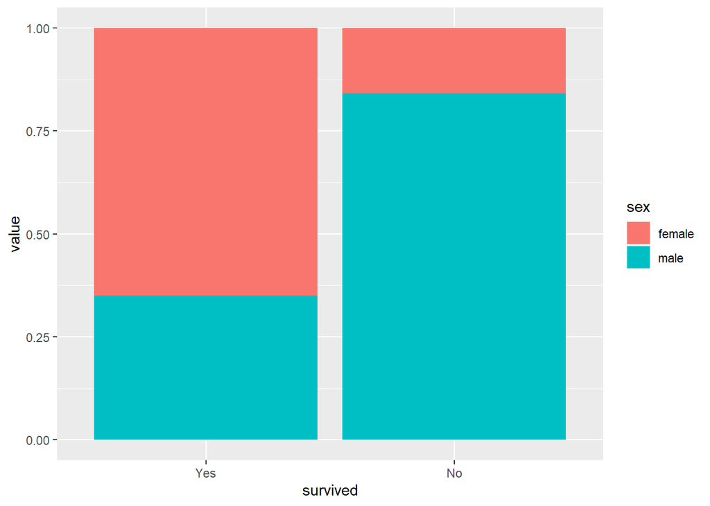

```r
value <- abs(rnorm(623,0,15))

#create the sex bar chart
ggplot(titanic_train, aes(fill=sex, y=value, x=survived)) +
  geom_bar(position="fill", stat="identity")
```

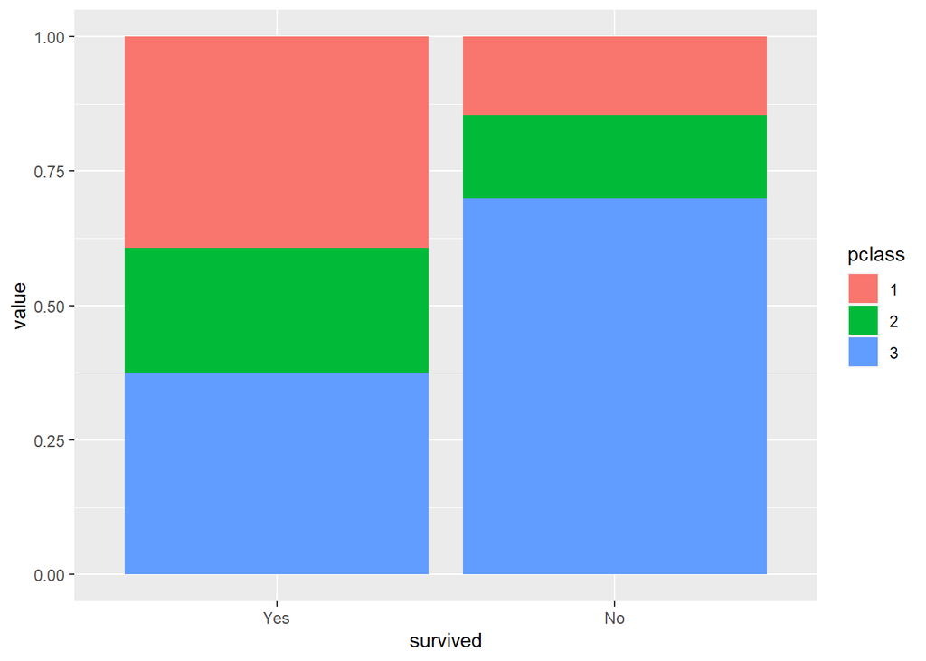

```r
#create the pclass bar chart
ggplot(titanic_train, aes(fill=pclass, y=value, x=survived)) +
  geom_bar(position="fill", stat="identity")
```

Based on both of these charts I believe that pclass and gender will be an excellent predictor of survival. A percentage stacked bar chart is more useful than a traditional stacked bar chart because a percentage stacked bar chart scales for how big the survived groups are. Thus, while more people died on the titanic than survived, this bar chart scales that detail.

### Question 3

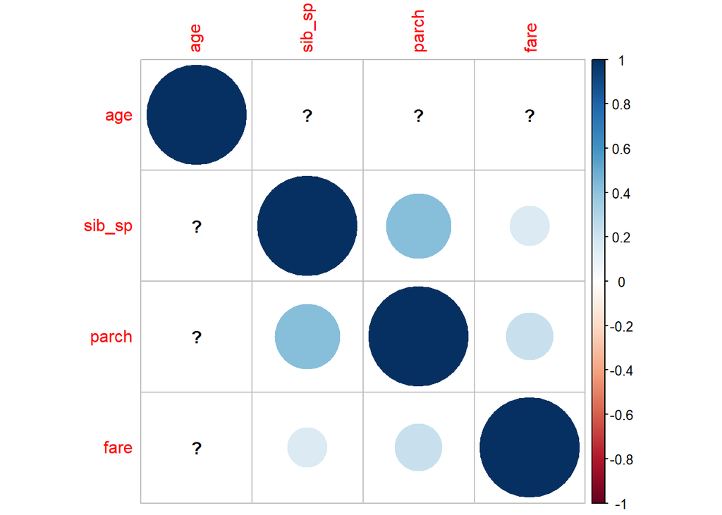

```r
only_numeric_titanic <- select(titanic_train, -passenger_id, -survived, -name, -sex, -ticket, -cabin, -embarked, -pclass)
only_numeric_titanic %>%
  cor() %>%
  corrplot()
```

### Question 4

```r
#create the recipe (note that this is where we impute age)
titanic_recipe <- recipe(survived ~ pclass + sex + age + sib_sp + parch + fare, titanic_train) %>%
  step_impute_linear(age, impute_with = imp_vars(pclass, sex, sib_sp, parch, fare)) %>%
  step_dummy(all_nominal_predictors()) %>%
  step_interact(~starts_with("sex"):age + age:fare)
```

### Question 5

```r
#specifying the engine
log_reg <- logistic_reg() %>%
  set_engine("glm") %>%
  set_mode("classification")

#setting up the workflow
titanic_log_wkflow <- workflow() %>%
  add_model(log_reg) %>%
  add_recipe(titanic_recipe)

#fit model
titanic_log_fit <- fit(titanic_log_wkflow, titanic_train)
```

### Question 6

```r
#specifying the engine
lda_mod <- discrim_linear() %>%
  set_mode("classification") %>%
  set_engine("MASS")

#setting up the workflow
titanic_LDA_wkflow <- workflow() %>%
  add_model(lda_mod) %>%
  add_recipe(titanic_recipe)

#fit model
titanic_LDA_fit <- fit(titanic_LDA_wkflow, titanic_train)
```

### Question 7

```r
#specify the engine
quad_discrim <- discrim_quad() %>%
  set_mode("classification") %>%
  set_engine("MASS")

#setting up the workflow
titanic_quad_discrim_wkflow <- workflow() %>%
  add_model(quad_discrim) %>%
  add_recipe(titanic_recipe)

#fit model
titanic_quad_fit <- fit(titanic_quad_discrim_wkflow, titanic_train)
```

### Question 8

```r
#specify the engine
knn_mod <- nearest_neighbor(neighbors=4) %>%
  set_mode("classification") %>%
  set_engine("kknn")

#setting up the workflow
titanic_knn_wrkflow <- workflow() %>%
  add_model(knn_mod) %>%
  add_recipe(titanic_recipe)

#fit model
titanic_knn_fit <- fit(titanic_knn_wrkflow, titanic_train)
```

### Question 9

```r
#fit the model to our testing data
test_titanic_log_fit <- fit(titanic_log_fit, titanic_test)

#set up the ROC curve
titanic_log_augment <- augment(test_titanic_log_fit, new_data=titanic_test)

#predict values for titanic
titanic_log_predict <- predict(test_titanic_log_fit, titanic_test %>% select(-survived))

#bind the predicted values with the testing dataset
titanic_log_bind <- bind_cols(titanic_log_predict, titanic_test %>%  select(survived))

#repeat for linear discriminate analysis
test_titanic_LDA_fit <- fit(titanic_LDA_fit, titanic_test)
titanic_LDA_augment <- augment(test_titanic_LDA_fit, new_data=titanic_test)
titanic_LDA_predict <- predict(test_titanic_LDA_fit, titanic_test %>% select(-survived))
titanic_LDA_bind <- bind_cols(titanic_LDA_predict, titanic_test %>%  select(survived))

#repeat for quadratic discriminate analysis
test_titanic_quad_fit <- fit(titanic_quad_fit, titanic_test)
titanic_quad_augment <- augment(test_titanic_quad_fit, new_data=titanic_test)
titanic_quad_predict <- predict(test_titanic_quad_fit, titanic_test %>% select(-survived))
titanic_quad_bind <- bind_cols(titanic_quad_predict, titanic_test %>% select(survived))

#repeat for k nearest neighbors
test_titanic_knn_fit <- fit(titanic_knn_fit, titanic_test)
titanic_knn_augment <- augment(test_titanic_knn_fit, new_data=titanic_test)
titanic_knn_predict <- predict(test_titanic_knn_fit, titanic_test %>% select(-survived))
titanic_knn_bind <- bind_cols(titanic_knn_predict, titanic_test %>% select(survived))

#area under curve for ROC for log
titanic_log_augment %>%
  roc_auc(survived, .pred_Yes)
```

```
## # A tibble: 1 × 3
##   .metric .estimator .estimate
##   <chr>   <chr>          <dbl>
## 1 roc_auc binary         0.842
```

```r
#area under curve for ROC for linear discriminate analysis
titanic_LDA_augment %>%
  roc_auc(survived, .pred_Yes)
```

```
## # A tibble: 1 × 3
##   .metric .estimator .estimate
##   <chr>   <chr>          <dbl>
## 1 roc_auc binary         0.833
```

```r
#area under curve for ROC for quadratic discriminate analysis
titanic_quad_augment %>%
  roc_auc(survived, .pred_Yes)
```

```
## # A tibble: 1 × 3
##   .metric .estimator .estimate
##   <chr>   <chr>          <dbl>
## 1 roc_auc binary         0.832
```

```r
#area under curve for k-nearest neighbors
titanic_knn_augment %>%
  roc_auc(survived, .pred_Yes)
```

```
## # A tibble: 1 × 3
##   .metric .estimator .estimate
##   <chr>   <chr>          <dbl>
## 1 roc_auc binary         0.996
```

### Question 10

The AUC for the logistic regression is 0.8421. The AUC for the linear discriminant analysis is 0.8328. The AUC for the quadratic discriminant analysis is 0.8324. The AUC for the k-nearest neighbors model is 0.9961. Therefore the best performing model by far is the KNN model. It should be noted that all models did perform well.

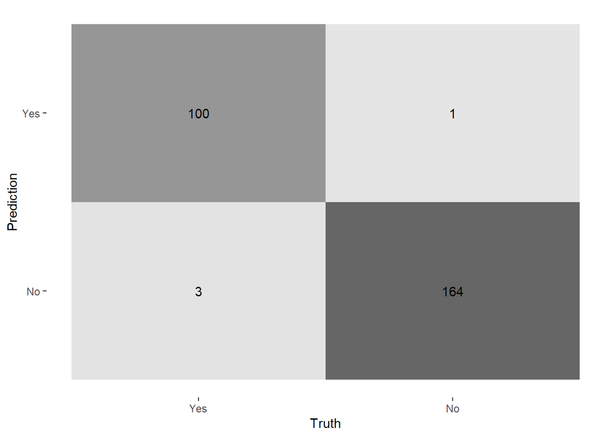

```r
#create the confusion matrix
titanic_knn_augment %>%
  conf_mat(truth=survived, estimate=.pred_class) %>%
  autoplot(type='heatmap')
```

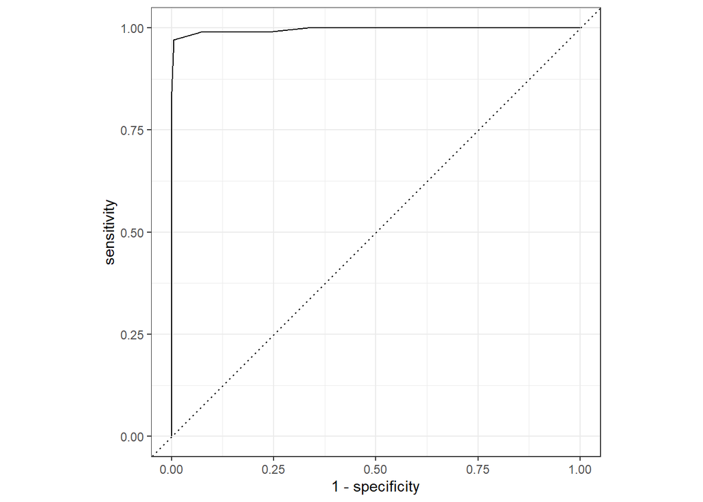

```r
#create the ROC curve
titanic_knn_augment %>%
  roc_curve(survived, .pred_Yes) %>%
  autoplot()
```

According to this, the KNN model performed extremely well. I am very impressed.

```r
#set up the ROC
titanic_knn_augment_train <- augment(titanic_knn_fit, new_data=titanic_train)

#find AUC
titanic_knn_augment_train  %>%
  roc_auc(survived, .pred_Yes)
```

```
## # A tibble: 1 × 3
##   .metric .estimator .estimate
##   <chr>   <chr>          <dbl>
## 1 roc_auc binary         0.995
```

The training model has an extremely high KNN value of 0.9954. The values are basically the same but the AUC is actually higher for the testing data. This is interesting and shows that the KNN model did not overfit. There should be low bias in this model.